# Netflix

2023-12-13

Lecture de la table

```r
netflix = read.csv("D:/netflix_titles.csv")
View(netflix)
```

La description des données nombre de lignes, de colonnes, de valeurs manquantes

```r
#install.packages("dplyr")
#install.packages("psych")
library(dplyr)
library(psych)
describe(netflix %>% select(type, title, director, country, listed_in))
```

```
##            vars    n    mean      sd median trimmed     mad min  max range
## type*         1 8807    1.30    0.46      1    1.25    0.00   1    2     1
## title*        2 8807 4404.00 2542.51   4404 4404.00 3264.69   1 8807  8806
## director*     3 8807 1625.83 1525.04   1361 1504.78 2016.34   1 4529  4528
## country*      4 8807  388.52  222.56    437  406.00  249.08   1  749   748
## listed_in*    5 8807  273.40  131.06    290  278.41  131.95   1  514   513
##             skew kurtosis    se
## type*       0.85    -1.27  0.00
## title*      0.00    -1.20 27.09
## director*   0.38    -1.31 16.25
## country*   -0.44    -1.19  2.37
## listed_in* -0.31    -0.76  1.40
```

Nous avons dans un premier temps voulu calculer la moyenne de la variable duration mais elle n’est pas numérique, on ne peut avoir sa moyenne mais nous avons le nombre d’observations qui est de 8807. Nous avons par la suite calculer la moyenne de la variable release_year, qui est de 2014,18 cela représente la moyenne des années de la sortie des films ou séries. Diagramme en barre de la distribution de la variable Type. On remarque que le type Movie et plus présent que le type Tv Show

```r
netflix %>% summarise(mean = mean(duration), n=n())
```

```
##   mean    n
## 1   NA 8807
```

```r
mean(netflix$release_year)
```

```
## [1] 2014.18
```

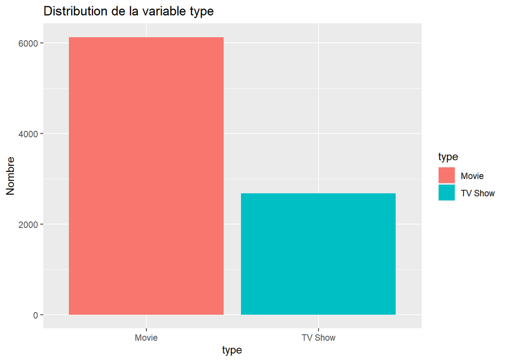

```r
#barplot(netflix$type, netflix$title)
#hist(table(netflix$type))


#install.packages("ggplot2")
library(ggplot2)
ggplot(netflix) + aes(x = type, fill=type) + geom_bar() + labs(fill = "type") + ylab("Nombre") + ggtitle("Distribution de la variable type")
```

Trie des pays dans l’ordre décroissant, on exclue les cases vides.

On choisi le top 10 des pays avec le plus de films/séries. On observe que les Etats-Unis est le pays avec le plus de films/séries et l’Egypte et le pays avec le moins de films/séries dans ce classement.

```r
p = sort(table(netflix$country, exclude = ""), decreasing = TRUE)
# On choisi les 10 pays avec le plus de films et séries
top10pays = head(p, 10)
top10pays
```

```
##
##  United States          India United Kingdom          Japan    South Korea
##           2818            972            419            245            199
##         Canada          Spain         France         Mexico          Egypt
##            181            145            124            110            106
```

```r
top10pays = data.frame(top10pays)
View(top10pays)
```

Diagramme en barre représentant la répartition des pays avec le plus de film et de série, on remarque par l’intérmédiaire de notre diagramme que les Etats-Unis est le pays qui possède le plus de films/séries avec 2818 films/séries, comme dit précédemment.

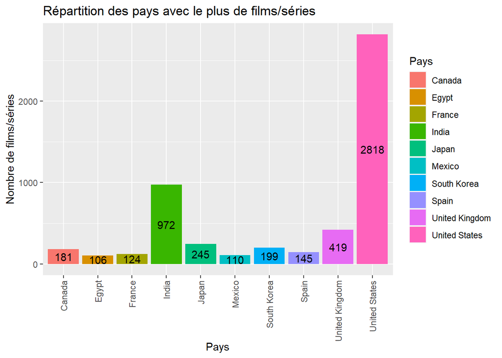

```r
t10p = netflix %>% filter(country %in% top10pays$Var1)

ggplot(t10p, aes(country, fill=country)) + geom_bar() +
  theme(axis.text.x = element_text(angle = 90, vjust = 0.5, hjust=1)) +
  geom_text(aes(label = after_stat(count)), stat = "count", position = position_stack(.5))+
  xlab("Pays") + ylab("Nombre de films/séries") + ggtitle("Répartition des pays avec le plus de films/séries") + labs(fill ="Pays")
```

```r
#ggplot(top10pays) + aes(x=Var1, fill=Freq) + geom_bar() +labs(fill = "Pays") + theme(axis.text.x = element_text(angle = 90, vjust = 0.5, hjust=1))
```

Nous avons ici fait un diagramme en barre de la répartition des directeurs avec le plus de films/séries, Rajiv Chilaka et Raul Campos, Jan Suter sont ceux qui possède le plus de film réalisé.

```r
d = sort(table(netflix$director, exclude = ""), decreasing = TRUE)
# On choisi les 10 pays avec le plus de films
top10directeurs = head(d, 10)
top10directeurs = data.frame(top10directeurs)
top10directeurs
```

```
##                      Var1 Freq
## 1           Rajiv Chilaka   19
## 2  Raúl Campos, Jan Suter   18
## 3            Marcus Raboy   16
## 4             Suhas Kadav   16
## 5               Jay Karas   14
## 6     Cathy Garcia-Molina   13
## 7             Jay Chapman   12
## 8         Martin Scorsese   12
## 9         Youssef Chahine   12
## 10       Steven Spielberg   11
```

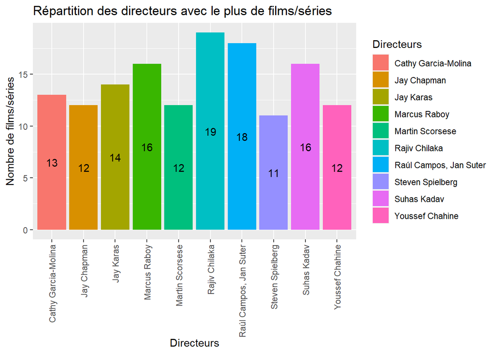

```r
t10d = netflix %>% filter(director %in% top10directeurs$Var1)
ggplot(t10d, aes(x=director, fill = director)) + geom_bar() +
  theme(axis.text.x = element_text(angle = 90, vjust = 0.5, hjust=1)) +
  geom_text(aes(label = after_stat(count)), stat = "count", position = position_stack(.5)) +
  labs(fill = "Directeurs") + xlab("Directeurs") + ylab("Nombre de films/séries") + ggtitle("Répartition des directeurs avec le plus de films/séries")
```

Nous avons ici réalisés un diagramme en barre représentant quel est la répartition du type en fonction du directeur. On remarque que la plupart des directeurs possèdent des films, le seul à possèder des séries est Marcus Raboy.

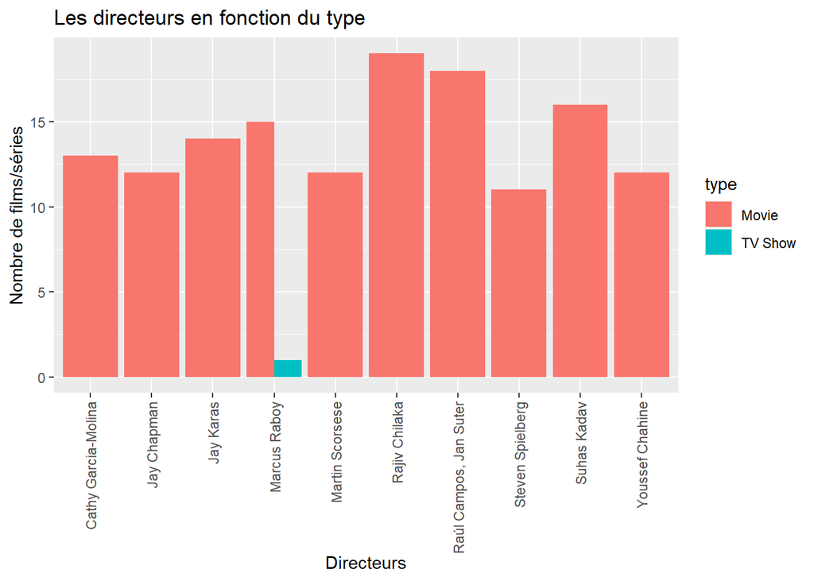

```r
ggplot(t10d, aes(x=director, fill=type)) + geom_bar(position = "dodge") +
  theme(axis.text.x = element_text(angle = 90, vjust = 0.5, hjust=1)) +
  xlab("Directeurs") + ylab("Nombre de films/séries") + ggtitle("Les directeurs en fonction du type")
```

```r
#ggplot(top10directeurs) + aes(x=Var1, fill=Freq) + geom_bar() +labs(fill = "Pays") + theme(axis.text.x = element_text(angle = 90, vjust = 0.5, hjust=1))
```

Nous remarquons grace au diagramme en barre qui représentent les années en fonction du type que en 2021 le nombre de séries et supérieur au nombre de films produits tandis que toutes les autres années le nombre de films et nettement supérieur au nombre de série. Ce qui veut que les directeurs produisent plus de série que de film car ils s’adaptent à la préférence des utilisateurs de la plateforme.

```r
sort(table(netflix$release_year), decreasing = TRUE)
```

```
##
## 2018 2017 2019 2020 2016 2021 2015 2014 2013 2012 2010 2011 2009 2008 2006 2007
## 1147 1032 1030  953  902  592  560  352  288  237  194  185  152  136   96   88
## 2005 2004 2003 2002 2001 1999 1997 2000 1998 1993 1995 1996 1992 1990 1994 1988
##   80   64   61   51   45   39   38   37   36   28   25   24   23   22   22   18
## 1982 1991 1989 1981 1986 1984 1979 1980 1983 1973 1985 1976 1987 1974 1975 1977
##   17   17   16   13   13   12   11   11   11   10   10    9    8    7    7    7
## 1978 1967 1971 1972 1945 1960 1943 1944 1955 1958 1962 1968 1942 1946 1954 1956
##    7    5    5    5    4    4    3    3    3    3    3    3    2    2    2    2
## 1963 1964 1965 1969 1970 1925 1947 1959 1961 1966
##    2    2    2    2    2    1    1    1    1    1
```

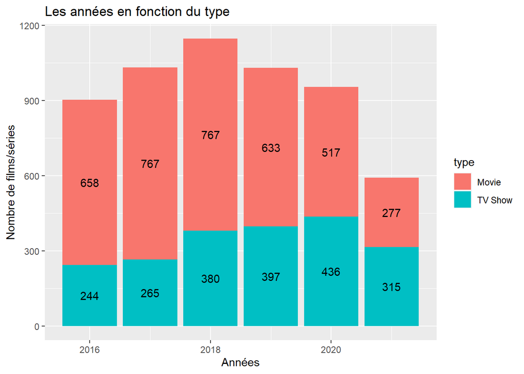

```r
top6annees = netflix %>% filter(between(release_year,2016, 2021))


ggplot(top6annees, aes(release_year, fill = type)) +
  geom_bar() + labs(fill= "type") +
  geom_text(aes(label = after_stat(count)), stat = "count", position = position_stack(.5)) +
  xlab("Années") + ylab("Nombre de films/séries") + ggtitle("Les années en fonction du type")
```

Diagramme en barre des pays en fonction du type, les Etats-Unis est le pays avec le plus de films et de séries.

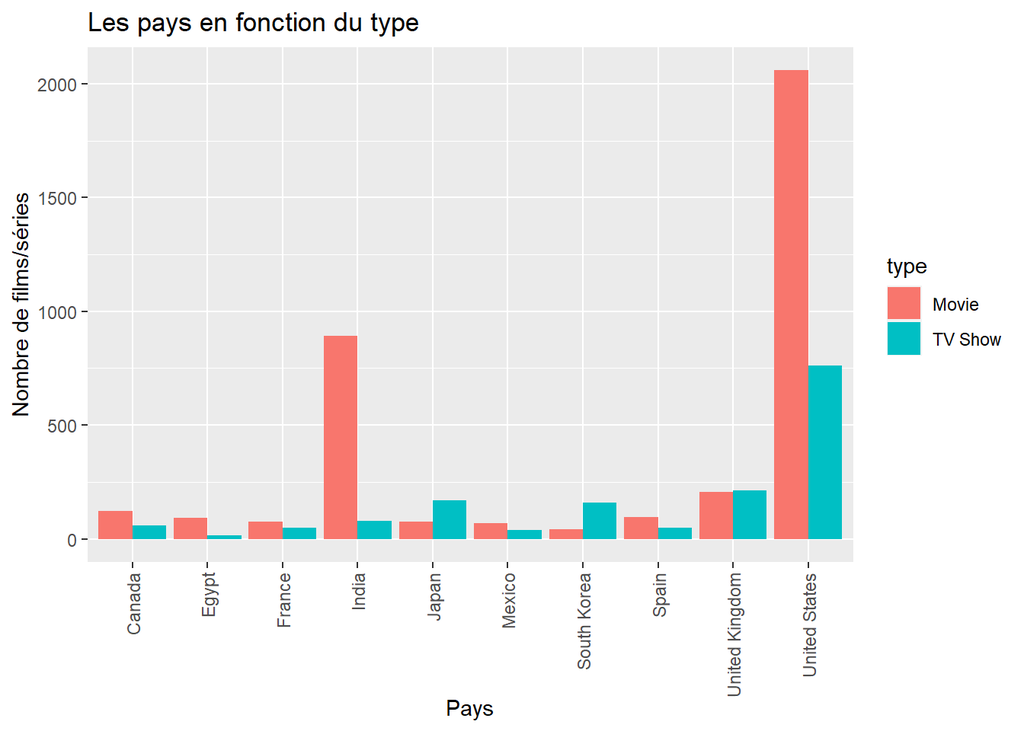

```r
ggplot(t10p, aes(x=country, fill=type)) + geom_bar(position = "dodge") +
  theme(axis.text.x = element_text(angle = 90, vjust = 0.5, hjust=1)) +
  xlab("Pays") + ylab("Nombre de films/séries") + ggtitle("Les pays en fonction du type")
```

Diagramme en barre horizontal qui représente la répartition des genres de films/séries les plus populaires. Les Dramas, International Movies ainsi que les documentaires sont les genres les plus populaires.

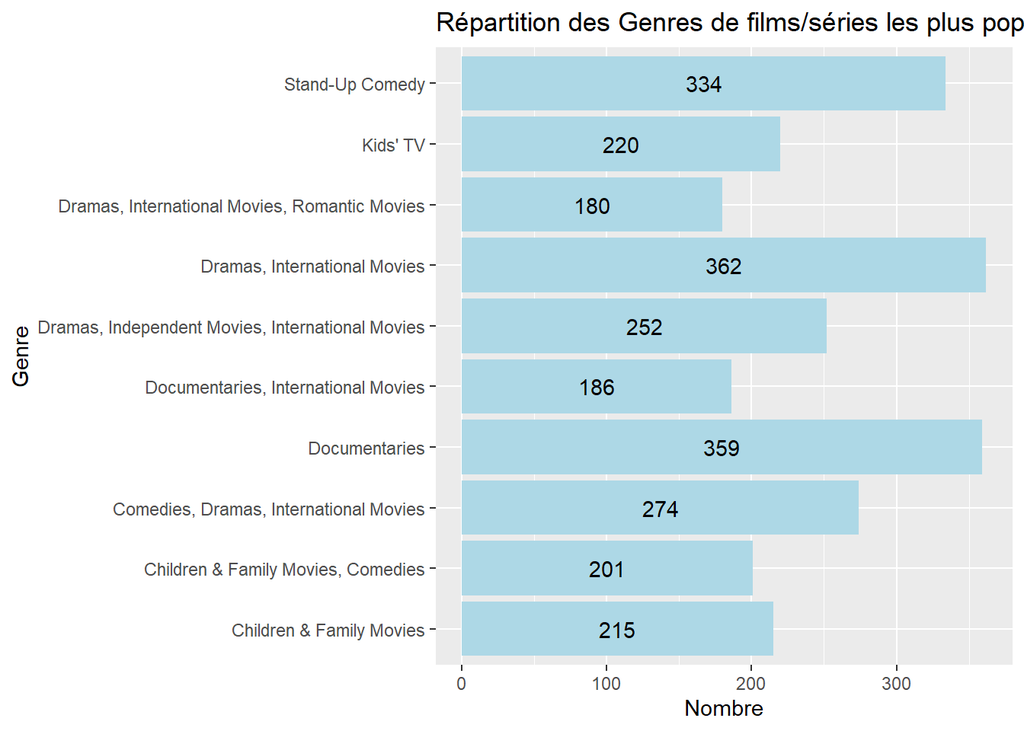

```r
g = sort(table(netflix$listed_in, exclude = ""), decreasing = TRUE)
# On choisi les 10 pays avec le plus de films
top10genres = head(g, 10)
top10genres = data.frame(top10genres)

t10g = netflix %>% filter(listed_in %in% top10genres$Var1)

ggplot(t10g, aes(y=listed_in)) + geom_bar(fill = "lightblue") +
  geom_text(aes(label = after_stat(count)), stat = "count", position = position_stack(.5)) +
  xlab("Nombre") + ylab("Genre") + ggtitle("Répartition des Genres de films/séries les plus populaires")
```

Diagramme en barre horizontal qui représente la répartition du genre en fonction du type on remarque que les séries sont seulement des Kids’Tv tandis que les autres genres sont des films.

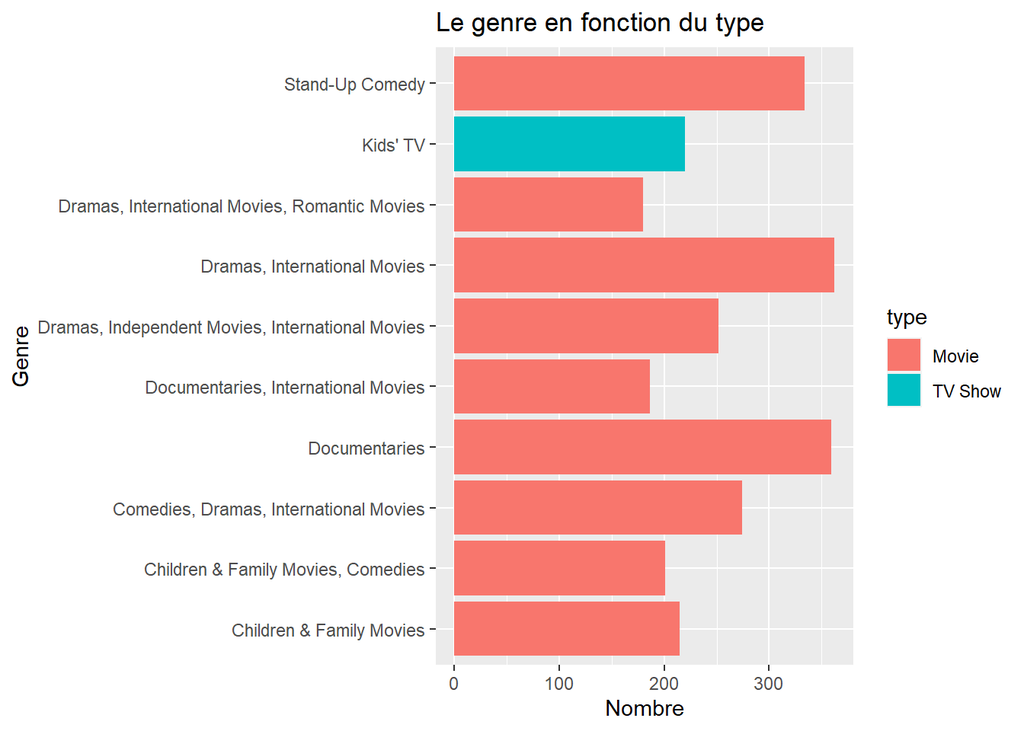

```r
ggplot(t10g, aes(y=listed_in, fill = type)) + geom_bar() + xlab("Nombre") + ylab("Genre") + ggtitle("Le genre en fonction du type")
```

Carte intéractif avec le top 10 pays contenat le plus de film/série produits.

```r
#install.packages("leaflet")
library(leaflet)
```

```r
countries_data <- data.frame(
  country = c("United States", "India", "United Kingdom", "Japan", "South Korea", "Canada", "Spain", "France", "Mexico", "Egypt"),
  occurrences = c(2818, 972, 419, 245, 199, 181, 145, 124, 110, 106),
  lat = c(37.7749, 20.5937, 51.5099, 36.2048, 35.9078, 56.1304, 40.4637, 46.6035, 23.6345, 26.8206),
  lon = c(-122.4194, 78.9629, -0.1180, 138.2529, 127.7669, -106.3468, -3.7492, 1.8883, -102.5528, 30.8025)
)

# Création de la carte interactive avec des marqueurs
map <- leaflet(countries_data) %>%
  addTiles() %>%
  addMarkers(
    lng = ~lon,
    lat = ~lat,
    popup = ~paste(country, "<br>Occurrences: ", occurrences)
  )

map
```

[interactive chart not shown]

Conclusion: On remarque que les Etats-Unis est le pays avec le plus de séries et films produits, que le nombre de séries est inférieur au nombre de films dans sa globalité mais à partir de 2021 la tendances est entrain de s’inverser le nombres de séries et supérieur au nombre de films.